# Project 2 -Model to predict performance of employees (Teach For India)

```python
# Let's import important library

import numpy as np
import pandas as pd
import seaborn as sns
import matplotlib.pyplot as plt
import warnings
warnings.filterwarnings('ignore')
```

```python
# Lets import datasets

data = pd.read_csv('C:/Users/hp/Downloads/Train_data.csv')
```

```python
data.head()
```

|  | employee_id | department | region | education | gender | recruitment_channel | no_of_trainings | age | previous_year_rating | length_of_service | KPIs_met >80% | awards_won? | avg_training_score | is_promoted |
| --- | --- | --- | --- | --- | --- | --- | --- | --- | --- | --- | --- | --- | --- | --- |
| 0 | 65438 | Sales & Marketing | region_7 | Master's & above | f | sourcing | 1 | 35 | 5.0 | 8 | 1 | 0 | 49 | 0 |
| 1 | 65141 | Operations | region_22 | Bachelor's | m | other | 1 | 30 | 5.0 | 4 | 0 | 0 | 60 | 0 |
| 2 | 7513 | Sales & Marketing | region_19 | Bachelor's | m | sourcing | 1 | 34 | 3.0 | 7 | 0 | 0 | 50 | 0 |
| 3 | 2542 | Sales & Marketing | region_23 | Bachelor's | m | other | 2 | 39 | 1.0 | 10 | 0 | 0 | 50 | 0 |
| 4 | 48945 | Technology | region_26 | Bachelor's | m | other | 1 | 45 | 3.0 | 2 | 0 | 0 | 73 | 0 |

```python
data.shape
```

```
(54808, 14)
```

```python
data.isnull().sum()
```

```
employee_id                0
department                 0
region                     0
education               2409
gender                     0
recruitment_channel        0
no_of_trainings            0
age                        0
previous_year_rating    4124
length_of_service          0
KPIs_met >80%              0
awards_won?                0
avg_training_score         0
is_promoted                0
dtype: int64
```

```python
data = data.dropna(subset=['education'])
```

```python
data.isnull().sum()
```

```
employee_id                0
department                 0
region                     0
education                  0
gender                     0
recruitment_channel        0
no_of_trainings            0
age                        0
previous_year_rating    3739
length_of_service          0
KPIs_met >80%              0
awards_won?                0
avg_training_score         0
is_promoted                0
dtype: int64
```

```python
mean_data = data['previous_year_rating'].mean()
```

```python
mean_data = round(mean_data,0)
mean_data
```

```
3.0
```

```python
data = data.fillna(mean_data)
```

```python
data.isnull().sum()
```

```
employee_id             0
department              0
region                  0
education               0
gender                  0
recruitment_channel     0
no_of_trainings         0
age                     0
previous_year_rating    0
length_of_service       0
KPIs_met >80%           0
awards_won?             0
avg_training_score      0
is_promoted             0
dtype: int64
```

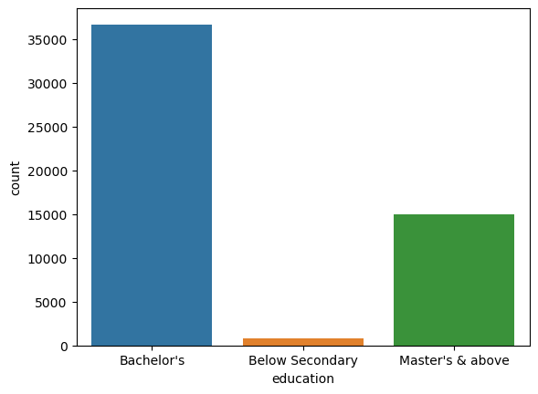

```python
sns.countplot(x= data['education'].sort_values())
```

Above graph is the reprentation of educational background of employees in the company.

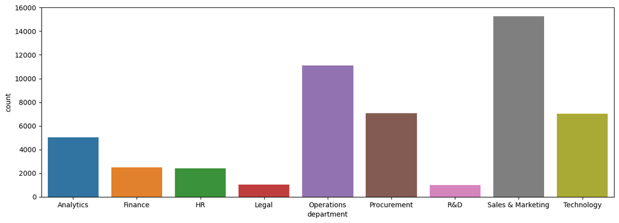

```python
plt.figure(figsize =(15,5))

sns.countplot( x= data['department'].sort_values())
```

Above chart shows us the employee strength in different departments. We can conclude Salses & Marketing team has the most employee. whereas R$D department strength is least among the group.

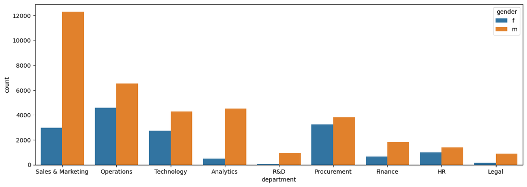

```python
# Male & Female in each Departments


plt.figure(figsize= (15,5))
sns.countplot( x= data['department'], hue =data['gender'])
```

Above graph represents the Male and Female comparisions in the departments of a company. Sales & Marketing department has great difference between Male & Femal Employees

```python
#Grphical reprentation of Male & Female employee with age as factor.

group_by = data.groupby('gender')['age'].mean()
group_by
```

```
gender
f    35.017210
m    34.964088
Name: age, dtype: float64
```

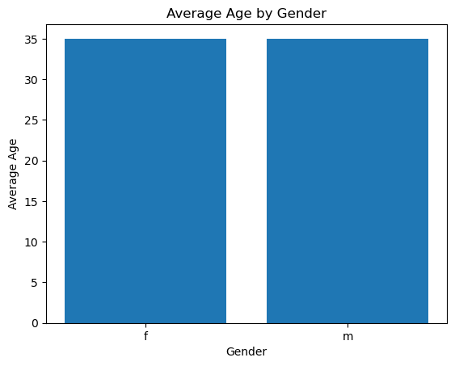

```python
plt.bar(group_by.index, group_by.values)
plt.xlabel('Gender')
plt.ylabel('Average Age')
plt.title('Average Age by Gender')
plt.show()
```

We can conclude that the average age of the male female are same in the organisation

```python
# Lets do correlation test to check

corr = data.corr()
corr
```

|  | employee_id | no_of_trainings | age | previous_year_rating | length_of_service | KPIs_met >80% | awards_won? | avg_training_score | is_promoted |
| --- | --- | --- | --- | --- | --- | --- | --- | --- | --- |
| employee_id | 1.000000 | -0.004701 | 0.000007 | 0.004128 | 0.000742 | -0.001677 | 0.007586 | -0.000042 | 0.000751 |
| no_of_trainings | -0.004701 | 1.000000 | -0.082601 | -0.062662 | -0.057845 | -0.047344 | -0.007659 | 0.041124 | -0.025389 |
| age | 0.000007 | -0.082601 | 1.000000 | 0.025439 | 0.652379 | -0.030967 | -0.008209 | -0.060652 | -0.018920 |
| previous_year_rating | 0.004128 | -0.062662 | 0.025439 | 1.000000 | 0.021675 | 0.338513 | 0.026773 | 0.066736 | 0.152921 |
| length_of_service | 0.000742 | -0.057845 | 0.652379 | 0.021675 | 1.000000 | -0.082109 | -0.040140 | -0.045329 | -0.012167 |
| KPIs_met >80% | -0.001677 | -0.047344 | -0.030967 | 0.338513 | -0.082109 | 1.000000 | 0.095555 | 0.072899 | 0.219934 |
| awards_won? | 0.007586 | -0.007659 | -0.008209 | 0.026773 | -0.040140 | 0.095555 | 1.000000 | 0.072069 | 0.195451 |
| avg_training_score | -0.000042 | 0.041124 | -0.060652 | 0.066736 | -0.045329 | 0.072899 | 0.072069 | 1.000000 | 0.180489 |
| is_promoted | 0.000751 | -0.025389 | -0.018920 | 0.152921 | -0.012167 | 0.219934 | 0.195451 | 0.180489 | 1.000000 |

```
<function matplotlib.pyplot.show(close=None, block=None)>
```

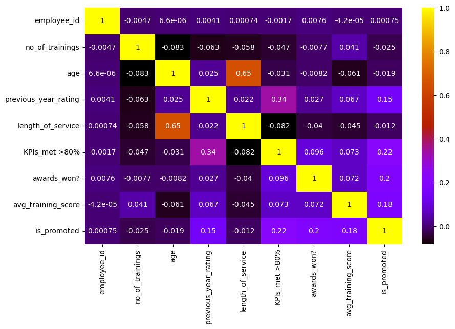

```python
plt.figure(figsize = (10,6))
sns.heatmap(corr, cmap = 'gnuplot', annot =True)
plt.show
```

As per the above chart Age and length_of_service is highly correlated so we will drop age & employee id as correlation between target column is very less. We are also dropping region as it does not play any role in performace prediction.

```python
data.head()
```

|  | employee_id | department | region | education | gender | recruitment_channel | no_of_trainings | age | previous_year_rating | length_of_service | KPIs_met >80% | awards_won? | avg_training_score | is_promoted |
| --- | --- | --- | --- | --- | --- | --- | --- | --- | --- | --- | --- | --- | --- | --- |
| 0 | 65438 | Sales & Marketing | region_7 | Master's & above | f | sourcing | 1 | 35 | 5.0 | 8 | 1 | 0 | 49 | 0 |
| 1 | 65141 | Operations | region_22 | Bachelor's | m | other | 1 | 30 | 5.0 | 4 | 0 | 0 | 60 | 0 |
| 2 | 7513 | Sales & Marketing | region_19 | Bachelor's | m | sourcing | 1 | 34 | 3.0 | 7 | 0 | 0 | 50 | 0 |
| 3 | 2542 | Sales & Marketing | region_23 | Bachelor's | m | other | 2 | 39 | 1.0 | 10 | 0 | 0 | 50 | 0 |
| 4 | 48945 | Technology | region_26 | Bachelor's | m | other | 1 | 45 | 3.0 | 2 | 0 | 0 | 73 | 0 |

```python
data = data.drop(columns = ['employee_id'])
```

```python
data = data.drop(columns = ['age'])
```

```python
data = data.drop(columns = ['recruitment_channel'])
```

```python
data =data.drop(columns = ['region'])
```

```python
data.head()
```

|  | department | education | gender | no_of_trainings | previous_year_rating | length_of_service | KPIs_met >80% | awards_won? | avg_training_score | is_promoted |
| --- | --- | --- | --- | --- | --- | --- | --- | --- | --- | --- |
| 0 | Sales & Marketing | Master's & above | f | 1 | 5.0 | 8 | 1 | 0 | 49 | 0 |
| 1 | Operations | Bachelor's | m | 1 | 5.0 | 4 | 0 | 0 | 60 | 0 |
| 2 | Sales & Marketing | Bachelor's | m | 1 | 3.0 | 7 | 0 | 0 | 50 | 0 |
| 3 | Sales & Marketing | Bachelor's | m | 2 | 1.0 | 10 | 0 | 0 | 50 | 0 |
| 4 | Technology | Bachelor's | m | 1 | 3.0 | 2 | 0 | 0 | 73 | 0 |

```python
#separating target variabel

A = data['is_promoted']
Y = pd.DataFrame(A, columns = ['is_promoted'])
Y.head()
```

|  | is_promoted |
| --- | --- |
| 0 | 0 |
| 1 | 0 |
| 2 | 0 |
| 3 | 0 |
| 4 | 0 |

```python
W = data.drop(columns = ['is_promoted'])
W.head()
```

|  | department | education | gender | no_of_trainings | previous_year_rating | length_of_service | KPIs_met >80% | awards_won? | avg_training_score |
| --- | --- | --- | --- | --- | --- | --- | --- | --- | --- |
| 0 | Sales & Marketing | Master's & above | f | 1 | 5.0 | 8 | 1 | 0 | 49 |
| 1 | Operations | Bachelor's | m | 1 | 5.0 | 4 | 0 | 0 | 60 |
| 2 | Sales & Marketing | Bachelor's | m | 1 | 3.0 | 7 | 0 | 0 | 50 |
| 3 | Sales & Marketing | Bachelor's | m | 2 | 1.0 | 10 | 0 | 0 | 50 |
| 4 | Technology | Bachelor's | m | 1 | 3.0 | 2 | 0 | 0 | 73 |

```python
W_cat = W.select_dtypes(np.object)
W_num = W.select_dtypes(np.number)
```

```python
W_cat.shape
```

```
(52399, 3)
```

```python
W_cat.head()
```

|  | department | education | gender |
| --- | --- | --- | --- |
| 0 | Sales & Marketing | Master's & above | f |
| 1 | Operations | Bachelor's | m |
| 2 | Sales & Marketing | Bachelor's | m |
| 3 | Sales & Marketing | Bachelor's | m |
| 4 | Technology | Bachelor's | m |

```python
W_num.head()
```

|  | no_of_trainings | previous_year_rating | length_of_service | KPIs_met >80% | awards_won? | avg_training_score |
| --- | --- | --- | --- | --- | --- | --- |
| 0 | 1 | 5.0 | 8 | 1 | 0 | 49 |
| 1 | 1 | 5.0 | 4 | 0 | 0 | 60 |
| 2 | 1 | 3.0 | 7 | 0 | 0 | 50 |
| 3 | 2 | 1.0 | 10 | 0 | 0 | 50 |
| 4 | 1 | 3.0 | 2 | 0 | 0 | 73 |

```python
W_num.shape
```

```
(52399, 6)
```

```python
# Lets scale our numerical dataset and the concat it with our categorical dataset

from sklearn.preprocessing import StandardScaler, MinMaxScaler, RobustScaler, MaxAbsScaler
```

```python
scaler_type = ['standard', 'minmax', 'robust', 'maxabs']
scaler_type
```

```
['standard', 'minmax', 'robust', 'maxabs']
```

```python
def scale_dataset(W_num, scaler_type = 'standard'):

    if scaler_type == 'standard':
        scaler = StandardScaler()

    elif scaler_type == 'minmax':
        scaler = MinMaxScaler()

    elif scaler_type == 'robust':
        scaler = RobustScaler()

    elif scaler_type == 'maxabs':
        scaler = MaxAbsScaler()

    else:
        raise ValueError("Invalid scaler_type. Supported types are 'standard', 'minmax', 'robust', and 'maxabs'.")

    scaled_num = scaler.fit_transform(W_num)


    scaled_num = pd.DataFrame(scaled_num, columns=W_num.columns)

    return scaled_num
```

```python
scaled_standard = scale_dataset(W_num, scaler_type='standard')
scaled_standard.shape
```

```
(52399, 6)
```

```python
scaled_standard.info()
```

```
<class 'pandas.core.frame.DataFrame'>
RangeIndex: 52399 entries, 0 to 52398
Data columns (total 6 columns):
 #   Column                Non-Null Count  Dtype
---  ------                --------------  -----
 0   no_of_trainings       52399 non-null  float64
 1   previous_year_rating  52399 non-null  float64
 2   length_of_service     52399 non-null  float64
 3   KPIs_met >80%         52399 non-null  float64
 4   awards_won?           52399 non-null  float64
 5   avg_training_score    52399 non-null  float64
dtypes: float64(6)
memory usage: 2.4 MB
```

```python
data2 = pd.concat([W_cat,scaled_standard], axis = 1)
data2.shape
```

```
(54699, 9)
```

```python
scaled_standard.to_csv('Data_std.csv', index = True)
```

we will use np.hstack as pd.concat is not working properly here while concating the dataset it increasing the no of rows which is resulting in error while performing train and test split

```python
dta = pd.DataFrame(np.hstack([W_cat,scaled_standard]))
dta.shape
```

```
(52399, 9)
```

```python
dta.info()
```

```
<class 'pandas.core.frame.DataFrame'>
RangeIndex: 52399 entries, 0 to 52398
Data columns (total 9 columns):
 #   Column  Non-Null Count  Dtype
---  ------  --------------  -----
 0   0       52399 non-null  object
 1   1       52399 non-null  object
 2   2       52399 non-null  object
 3   3       52399 non-null  object
 4   4       52399 non-null  object
 5   5       52399 non-null  object
 6   6       52399 non-null  object
 7   7       52399 non-null  object
 8   8       52399 non-null  object
dtypes: object(9)
memory usage: 3.6+ MB
```

```python
dta.head()
```

|  | 0 | 1 | 2 | 3 | 4 | 5 | 6 | 7 | 8 |
| --- | --- | --- | --- | --- | --- | --- | --- | --- | --- |
| 0 | Sales & Marketing | Master's & above | f | -0.417644 | 1.387762 | 0.483454 | 1.342641 | -0.154006 | -1.099974 |
| 1 | Operations | Bachelor's | m | -0.417644 | 1.387762 | -0.451912 | -0.744801 | -0.154006 | -0.272768 |
| 2 | Sales & Marketing | Bachelor's | m | -0.417644 | -0.257911 | 0.249613 | -0.744801 | -0.154006 | -1.024774 |
| 3 | Sales & Marketing | Bachelor's | m | 1.212457 | -1.903583 | 0.951137 | -0.744801 | -0.154006 | -1.024774 |
| 4 | Technology | Bachelor's | m | -0.417644 | -0.257911 | -0.919595 | -0.744801 | -0.154006 | 0.704839 |

```python
dta.columns = W.columns
```

```python
dta.head()
```

|  | department | education | gender | no_of_trainings | previous_year_rating | length_of_service | KPIs_met >80% | awards_won? | avg_training_score |
| --- | --- | --- | --- | --- | --- | --- | --- | --- | --- |
| 0 | Sales & Marketing | Master's & above | f | -0.417644 | 1.387762 | 0.483454 | 1.342641 | -0.154006 | -1.099974 |
| 1 | Operations | Bachelor's | m | -0.417644 | 1.387762 | -0.451912 | -0.744801 | -0.154006 | -0.272768 |
| 2 | Sales & Marketing | Bachelor's | m | -0.417644 | -0.257911 | 0.249613 | -0.744801 | -0.154006 | -1.024774 |
| 3 | Sales & Marketing | Bachelor's | m | 1.212457 | -1.903583 | 0.951137 | -0.744801 | -0.154006 | -1.024774 |
| 4 | Technology | Bachelor's | m | -0.417644 | -0.257911 | -0.919595 | -0.744801 | -0.154006 | 0.704839 |

```python
dta.info()
```

```
<class 'pandas.core.frame.DataFrame'>
RangeIndex: 52399 entries, 0 to 52398
Data columns (total 9 columns):
 #   Column                Non-Null Count  Dtype
---  ------                --------------  -----
 0   department            52399 non-null  object
 1   education             52399 non-null  object
 2   gender                52399 non-null  object
 3   no_of_trainings       52399 non-null  object
 4   previous_year_rating  52399 non-null  object
 5   length_of_service     52399 non-null  object
 6   KPIs_met >80%         52399 non-null  object
 7   awards_won?           52399 non-null  object
 8   avg_training_score    52399 non-null  object
dtypes: object(9)
memory usage: 3.6+ MB
```

```python
col = ['no_of_trainings', 'previous_year_rating','length_of_service','KPIs_met >80%','awards_won?','avg_training_score']
```

```python
dta[col] = dta[col].astype(float)
```

```python
dta.info()
```

```
<class 'pandas.core.frame.DataFrame'>
RangeIndex: 52399 entries, 0 to 52398
Data columns (total 9 columns):
 #   Column                Non-Null Count  Dtype
---  ------                --------------  -----
 0   department            52399 non-null  object
 1   education             52399 non-null  object
 2   gender                52399 non-null  object
 3   no_of_trainings       52399 non-null  float64
 4   previous_year_rating  52399 non-null  float64
 5   length_of_service     52399 non-null  float64
 6   KPIs_met >80%         52399 non-null  float64
 7   awards_won?           52399 non-null  float64
 8   avg_training_score    52399 non-null  float64
dtypes: float64(6), object(3)
memory usage: 3.6+ MB
```

```python
# List of categorical columns
cat_cols = ['department', 'education', 'gender']

# Convert categorical columns to category type
for col in cat_cols:
    dta[col] = dta[col].astype('category')
```

```python
dta.info()
```

```
<class 'pandas.core.frame.DataFrame'>
RangeIndex: 52399 entries, 0 to 52398
Data columns (total 9 columns):
 #   Column                Non-Null Count  Dtype
---  ------                --------------  -----
 0   department            52399 non-null  category
 1   education             52399 non-null  category
 2   gender                52399 non-null  category
 3   no_of_trainings       52399 non-null  float64
 4   previous_year_rating  52399 non-null  float64
 5   length_of_service     52399 non-null  float64
 6   KPIs_met >80%         52399 non-null  float64
 7   awards_won?           52399 non-null  float64
 8   avg_training_score    52399 non-null  float64
dtypes: category(3), float64(6)
memory usage: 2.5 MB
```

```python
import xgboost as xgb
from sklearn.model_selection import train_test_split
from sklearn.metrics import classification_report, confusion_matrix, accuracy_score
```

```python
#Splitting the dataset into test & train set

X_train, X_test, Y_train, Y_test = train_test_split(dta, Y, test_size=0.2, random_state=42)
X_train.shape, X_test.shape, Y_train.shape, Y_test.shape
```

```
((41919, 9), (10480, 9), (41919, 1), (10480, 1))
```